# Basics of Visualizations

Applied Statistics

MTH-361A | Spring 2026 | University of Portland

# Objectives

- **Know the basics of visualizing data**
- **Introduce the language of the `ggplot2` package**

# `tidyverse` Core Packages for Data Visualizations

`tidyverse` is a collection of packages suited for data processing and visualization.

Core packages specifically for data visualizations:

[figure not shown]

- `ggplot2` is a system for creating graphics, where you provide the data, specify how to map variables to plots, and it handles the details.

$\star$ Make sure that you load the `tidyverse` package before you use any functions in `ggplot2`.

```r
library(tidyverse)
```

# Data Visualization Using `ggplot2`

**What is `ggplot2`?**

- **Overview:**
  - `ggplot2` is a powerful R package designed for data visualizations.
  - It is part of the `tidyverse` ecosystem.
- **Key Features:**
  - Intuitive grammar for graphics.
  - Intuitive syntax with layering using the operator `+`.

**Why use `ggplot2`?**

- **Ease of Use:** Clear, human-readable code.
- **Efficiency:** Built-in functions optimized for performance.
- **Consistency:** Works seamlessly with other `tidyverse` packages such as `dplyr` for data wrangling.
- **Data Frames and Beyond:** Works with data frames, tibbles, and databases.

# The Grammar for Graphics

**What is the Grammar of Graphics?**

- The Grammar of Graphics is a systematic approach to building visualizations by breaking down graphs into fundamental components.
- The `ggplot2` package in R is based on this framework, allowing for a highly customizable and layered approach to data visualization.

# Key Components of `ggplot2`

- **Data:** The dataset being visualized in tibble form.
- **Aesthetics (aes):** The mapping of data variables to visual properties like position, color, size, and shape.
- **Geometries (geom):** The type of plot (e.g., points, lines, bars) that represents the data.
- **Facets:** Splitting data into multiple panels for comparison.
- **Statistics (stat):** Computations applied to the data before plotting (e.g., smoothing, binning).
- **Coordinates (coord):** The system defining how data is mapped onto the plot (e.g., Cartesian, polar).
- **Themes:** Controls the overall appearance of the plot, such as background color, grid lines, and fonts.

# Example: `iris` Data Set Scatter Plots

**Convert dataframe into `tibble`**

```r
# define dataframe as tibble
iris_tibble <- tibble(iris)
```

**Plotting `iris` lengths**

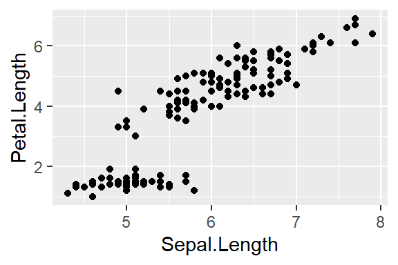

```r
# establish data and variables
ggplot(
    # dataframe
    iris_tibble,
    # aesthetics
    aes(
      # x-axis using a numerical variable
      x = Sepal.Length,
      # y-axis using a numerical variable
      y = Petal.Length
      )
    ) +
  # draw scatter plot
  geom_point()
```

**Layered Approach**

- **Base layer:** `ggplot(data, aes(...))` defines the dataset and variables.
- **Geometric layers:** `+ geom_*()` specifies the type of plot.
- **Other layers:** `+ facet_*(), + coord_*(), + theme_*()` enhance the visualization.

$\star$ Note that the `+` operator here is used to “add” a layer, not adding numbers.

# Aesthetics

The `aes()` function maps data variables to visual properties like position, color, size, and shape.

**Plotting `iris` lengths by species**

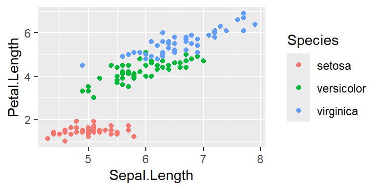

```r
# establish data and variables
ggplot(
    # dataframe
    iris_tibble,
    # aesthetics
    aes(
      # x-axis using a numerical variable
      x = Sepal.Length,
      # y-axis using a numerical variable
      y = Petal.Length,
      # color each point using a categorical variable
      color = Species
      )
    ) +
  # draw scatter plot
  geom_point()
```

**Common Aesthetics Mappings**

- **`x` and `y`:** Map variables to the horizontal and vertical axes.
- **`color`:** Assign colors to different categories.
- **`size`:** Control the size of points or lines based on a variable.
- **`shape`:** Change the shape of points according to a categorical variable.
- **`fill`:** Fill color of geometric objects of different categories.

$\star$ Note that the `aes()` function is called within the `ggplot()` function as the second argument.

# Layering

Using the `+` operator allows us to add layers to the plot, which is used for customizing the plot or adding more information.

**Plotting `iris` lengths by species with regression lines**

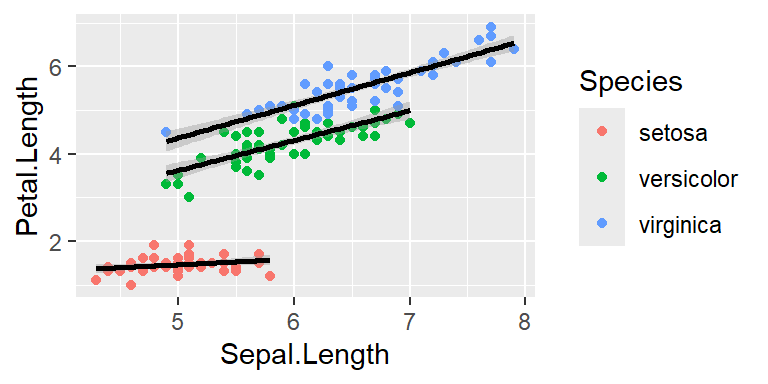

```r
# establish data and variables
ggplot(
    # dataframe
    iris_tibble,
    # aesthetics
    aes(
      # x-axis using a numerical variable
      x = Sepal.Length,
      # y-axis using a numerical variable
      y = Petal.Length,
      # color each point using a categorical variable
      color = Species,
      # color each point using a categorical variable
      group = Species
      )
    ) +
  # draw scatter plot
  geom_point() +
  # add regression lines
  geom_smooth(
    # define model
    method = 'lm', formula='y~x',
    # define color
    color = "black"
    )
```

**Layering to add more information**

- This example used the function `geom_smooth()`
- `geom_smooth()` fits a regression line to each group, then adds this line as a layer on the plot.

$\star$ **Key Idea:** All subsequent layers will inherit all information of the `aes()` variables defined in the `ggplot()` function.

# Common Geometries for Numerical Variables

| **Geom** | **Function** |
| --- | --- |
| `geom_point()` | Scatter plot for visualizing relationships between two numerical variables. |
| `geom_line()` | Line plot for trends over time or continuous sequences. |
| `geom_histogram()` | Histogram for visualizing the distribution of a single numerical variable. |
| `geom_dotplot()` | Shows each dot representing one observation in a distribution. |
| `geom_boxplot()` | Box plot for showing distributions and detecting outliers. |

$\star$ Be careful when defining variables in `aes()`. For example, `geom_histogram()` only requires an x-axis variable, as it plots the distribution of a single numerical variable.

# Example: `iris` Data Set Histogram

**Plotting the distribution of `iris` sepal lengths by species**

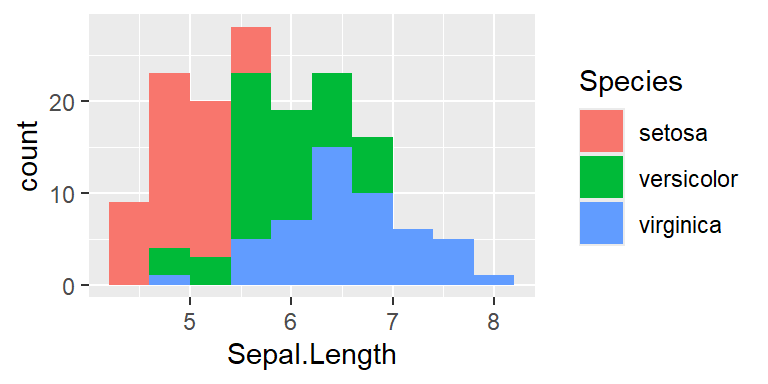

```r
# establish data and variables
ggplot(
    # dataframe
    iris_tibble,
    # aesthetics
    aes(
      # x-axis using a numerical variable
      x = Sepal.Length,
      # fill bars using a categorical variable
      fill = Species
      )
    ) +
  # draw histogram
  geom_histogram(
    # define number of bins
    bins=10
    )
```

$\star$ The `bins` parameter in the `geom_histogram()` function allows you to adjust the number of bins, affecting how the data is visualized.